# Análise Exploratória de Dados do e-SUS

16/07/2020

# 1 Descrição da atividade

Nesta atividade, você deve fazer uma análise exploratória dos dados do e-SUS Notifica, que possui dados de notificações de suspeitos e confirmados de COVID-19 nos municípios do Brasil.

Com base nas aulas anteriores, crie um novo projeto R para a sua análise, crie um documento Rmarkdown `.Rmd`, copie o código deste documento para iniciar e modifique o conteúdo para adicionar as seções, os textos e as visualizações que desejar. O ideal é que você também crie um repositório no Github para guardar seu código e análises.

Uma análise exploratória é guiada por perguntas, que levam a novas perguntas e assim por diante. Então, é importante informar quais perguntas você está tentando responder a partir de cada gráfico, número ou tabela exibido.

# 2 Carregando os dados

Visão geral dos dados:

```r
glimpse(esus_pb)
```

```
Rows: 263,177
Columns: 33
$ id                         <fct> 8qBdtBv7vS, NOOFMuVIYZ, ieblZ27mjN, 6glSoR…
$ data_notificacao           <date> 2020-05-21, 2020-05-21, 2020-05-21, 2020-…
$ data_inicio_sintomas       <date> 2020-05-05, 2020-05-12, 2020-05-18, 2020-…
$ data_nascimento            <date> 1979-10-11, 1989-01-02, 2001-11-01, 2020-…
$ sintomas                   <fct> "Dor de Garganta, Tosse, Outros", "Febre, …
$ profissional_saude         <fct> Não, Não, Não, Não, Não, Não, Não, Não, Nã…
$ cbo                        <fct> NA, NA, NA, NA, NA, NA, NA, NA, NA, "5151 …
$ condicoes                  <fct> "Doenças respiratórias crônicas descompens…
$ estado_teste               <fct> NA, NA, NA, Concluído, Solicitado, Solicit…
$ data_teste                 <date> NA, NA, NA, 2020-05-18, NA, NA, 2020-05-1…
$ tipo_teste                 <fct> NA, NA, NA, TESTE RÁPIDO - ANTICORPO, NA, …
$ resultado_teste            <fct> NA, NA, NA, Positivo, NA, NA, Negativo, Po…
$ pais_origem                <lgl> NA, NA, NA, NA, NA, NA, NA, NA, NA, NA, NA…
```

[output cut: 20 more lines]

# 3 Atributos para explorar

## 3.1 Tipos, resultados e estados dos teste

A coluna `resultado_teste` informa se o teste para COVID-19 foi Positivo, Negativo ou *NA* se ainda não há resultado registrado. Você pode ver a quantidade e percentual de cada um assim:

```r
esus_pb %>%
  group_by(resultado_teste) %>%
  summarise(quantidade = n()) %>% # n() aqui vai retornar a quantidade por grupo
  mutate(percentual = percent(quantidade / sum(quantidade), accuracy = 1))
```

| resultado_teste | quantidade | percentual |
| --- | --- | --- |
| Negativo | 131580 | 50% |
| Positivo | 66382 | 25% |
| NA | 65215 | 25% |

Observe que aproximadamente metade dos notificados testaram negativo, 25% testaram positivo e os outros 25% não possuem resultado de teste.

Você pode, por exemplo, fazer análises comparativas entre pacientes com resultados positivos e negativos.

A coluna `tipo_teste` indica qual tipo de teste para COVID-19 foi realizado.

A coluna `estado_teste` indica se o teste foi coletado, concluído, solicitado ou não solicitado.

## 3.2 Idade, sexo, profissão, localidade, comorbidades

A coluna `idade` informa a idade de cada paciente registrado. O que podemos extrair de informações importantes sobre as idades dos pacientes, através de análises e visualizações?

Estatísticas das idades dos pacientes registrados:

```r
summary(esus_pb$idade)
```

```
   Min. 1st Qu.  Median    Mean 3rd Qu.    Max.    NA's
    0.0    28.0    38.0    39.2    49.0   387.0       8
```

Podemos gerar um box-plot para visualizar as idades:

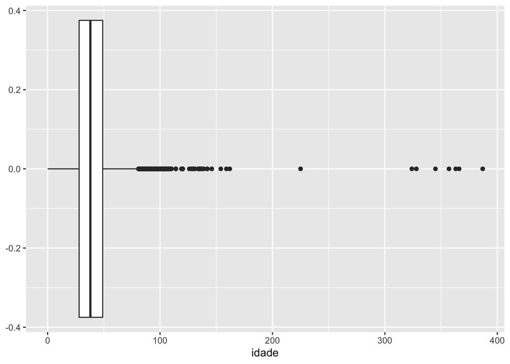

```r
ggplot(esus_pb, aes(idade)) +
  geom_boxplot()
```

Existem registros incomuns nos dados de idade? Lembre de remover os outliers e explicar como você fez isso ao realizar as análises de idade.

Você também pode definir uma nova categoria com base na faixa de idade, por exemplo analisar crianças (12 anos ou menos) e idosos (60 anos ou mais).

A coluna `sexo` indica se o paciente é do sexo Masculino ou Feminino.

As colunas `cbo` e `profissional_saude` indicam a profissão do paciente e se é da saúde.

Você podem iniciar com perguntas relacionadas à profissão dos pacientes, por exemplo: quais as 10 profissões com mais resultados positivos?

Também existem colunas relativas ao local de residência do paciente (`estado`, `municipio` `bairro`), além do estado e município onde o caso foi notificado.

A coluna `condicoes` indica as doenças prévias do paciente, que podem ser fator de risco.

## 3.3 Datas e tempos entre eventos

Existem registros de datas de eventos como `data_notificacao`, `data_inicio_sintomas`, `data_teste`, `data_encerramento`. Com essas datas, você pode calcular a quantidade de dias entre dois eventos. Por exemplo, um dado interessante de analisar é o tempo entre a data de primeiros sintomas e a data de teste:

```r
esus_pb <- esus_pb %>%
  mutate(tempo_sintomas_teste = as.integer(data_teste - data_inicio_sintomas))
```

# 4 Perguntas iniciais

Segue algumas perguntas iniciais para sua análise exploratória. A partir delas, você pode ir aprofundando sua análise. Além dessas, você deve levantar suas próprias questões e seguir fazendo levantamento de novas perguntas.

- Que sexo apresentou mais resultados positivos, homens ou mulheres? Qual a proporção de cada um?
- Quais as 5 profissões com mais casos confirmados (resultado de teste positivo)? Quantos casos para elas?
- Quais os 5 municípios com mais casos confirmados (resultado de teste positivo)? Quanto casos para eles?
- Qual a porcentagem de crianças que testaram positivo (menor ou igual a 12 anos)? E a de idoso (maior ou igual a 60 anos)?
- Quanto o tempo médio entre os primeiros sintomas e a data de teste para os diferentes tipos de teste?
- Qual dia teve a maior quantidade de início de sintomas para pacientes com teste positivo?